# CLASE 110-DATOS ORDINALES

## FRECUENCIA ABSOLUTA DE EJEMPLO 3

```r
frAbs=table(longitud)
frAbs
```

```
longitud
    Corto     Largo Muy corto Muy largo    Normal
       12         5        11        14         8
```

## FRECUENCIA RELATIVA EJEMPLO 3

```r
frRel=prop.table(frAbs)
frRel
```

```
longitud
    Corto     Largo Muy corto Muy largo    Normal
     0.24      0.10      0.22      0.28      0.16
```

## FRECUENCIAS ABSOLUTAS ACUMULADAS

```r
frAcum=cumsum(frAbs)
frAcum
```

```
    Corto     Largo Muy corto Muy largo    Normal
       12        17        28        42        50
```

## FRECUENCIA RELATIVA ACUMULADA

```r
frRAcum=cumsum(frRel)
frRAcum
```

```
    Corto     Largo Muy corto Muy largo    Normal
     0.24      0.34      0.56      0.84      1.00
```

## DIAGRAMA DE BARRAS DE FRECUENCIAS RELATIVAS ACUMULADAS

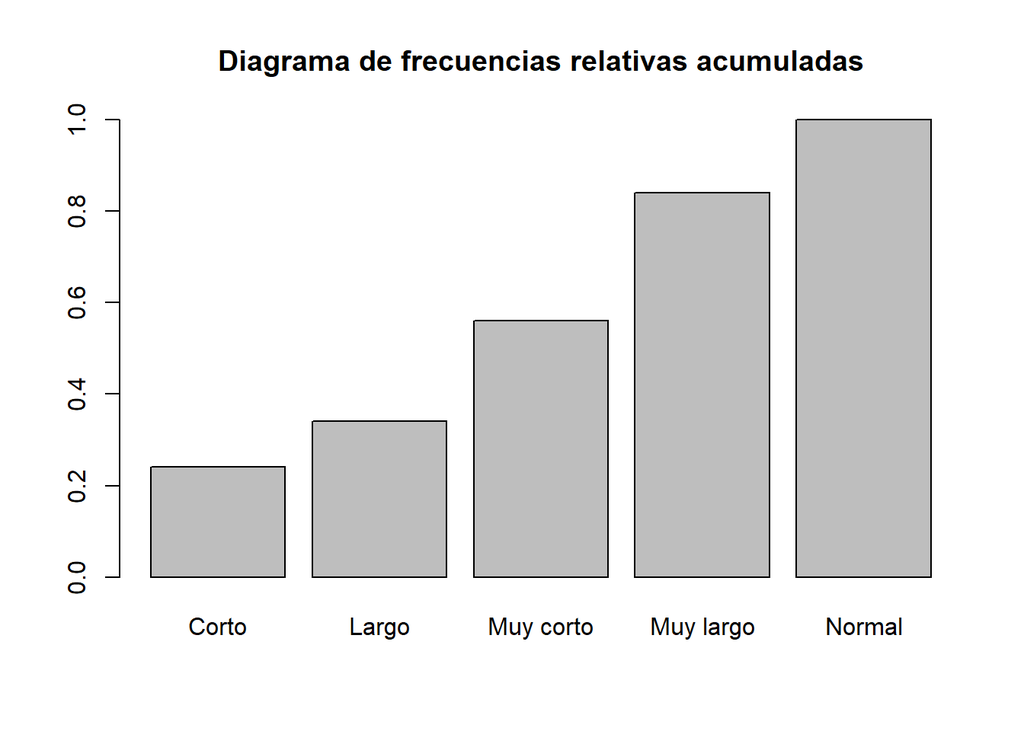

```r
barplot(frRAcum,main = "Diagrama de frecuencias relativas acumuladas")
```

# ANÁLISIS DE DATOS ORDINALES POR FACTOR

Para calcular frecuencias acumuladas en una tabla multidimensional, hay que aplicar a la tabla la funciopn cumsum mediante la funcion apply que ya explicabamos para matrices. En este caso concreto, al sintaxis de la instrucción sería

apply(tabla,MARGIN=…,FUN=cumsum)

donde el valor de MARGIN ha de ser el de la dimension en la que queremos acumular las frecuencias 1 si queremso hacerlo por filas 2 por si queremos hacerlo por columans etc.

## EJEMPLO 4

Vamos a organizasr todos estos datos en un dataframe llamado jirafas. Para q ue nos sea más fácil visualizar la información es conveniente que las filas de las tablas de frecuencais correspondan a las zonas. Por lo tanto, al definir el dataframe, entraremos como primera variable la de la muestra de las zonas. Así conseguiremos que éstas aparezcan en las filas al aplicarle la función table.

```r
zonas=rep(c("A","B","C","D"),c(30,25,35,10))
jirafas=data.frame(zonas,longitud)
jirafas$zonas=as.factor(jirafas$zonas)
str(jirafas)
```

```
'data.frame':   100 obs. of  2 variables:
 $ zonas   : Factor w/ 4 levels "A","B","C","D": 1 1 1 1 1 1 1 1 1 1 ...
 $ longitud: chr  "Corto" "Corto" "Muy corto" "Normal" ...
```

```r
head(jirafas)
```

```
  zonas  longitud
1     A     Corto
2     A     Corto
3     A Muy corto
4     A    Normal
5     A Muy corto
6     A Muy largo
```

### PARA CALCULAR LA TABLA DE FRECUENCACIS ABSOLUTAS ACUMULADAS

Para calcular la tabla de frecuencias absolutas acumuladas de las longitudes por zonas y como las zonas definen las filas de la tabla anterior, debemos utilizar la funcion apply con MARGIN=1.

```r
apply(table(jirafas), MARGIN=1,FUN=cumsum)
```

```
           zonas
longitud     A  B  C  D
  Corto     10  4  9  1
  Largo     14  5 14  1
  Muy corto 21 11 22  2
  Muy largo 28 18 33  5
  Normal    30 25 35 10
```

```r
t(apply(table(jirafas), MARGIN=1,FUN=cumsum))
```

```
     longitud
zonas Corto Largo Muy corto Muy largo Normal
    A    10    14        21        28     30
    B     4     5        11        18     25
    C     9    14        22        33     35
    D     1     1         2         5     10
```

Para calcular la tabla de frecuencias relativas acumuladas de las longitudes del cuello po zonas. Para conseguirlo, y en una unica instruccion, primero calculamos la tabla de frecuencias relativas por filas, a continuación, con las funciones apply y cumsum las acumulamos y finalmente transponemos el resultado.

```r
t(apply(prop.table(table(jirafas),margin=1),MARGIN=1, FUN=cumsum))
```

```
     longitud
zonas     Corto     Largo Muy corto Muy largo Normal
    A 0.3333333 0.4666667 0.7000000 0.9333333      1
    B 0.1600000 0.2000000 0.4400000 0.7200000      1
    C 0.2571429 0.4000000 0.6285714 0.9428571      1
    D 0.1000000 0.1000000 0.2000000 0.5000000      1
```

### DIAGRAMA DE BARRAS

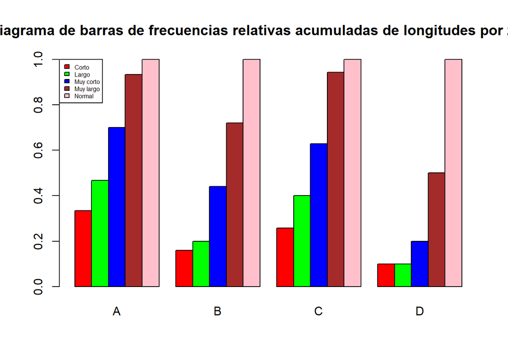

```r
Diagrama=apply(prop.table(table(jirafas),margin = 1),MARGIN=1, FUN=cumsum)
barplot(Diagrama,beside=TRUE,legend=TRUE,main="Diagrama de barras de frecuencias relativas acumuladas de longitudes por zonas",args.legend=list(x="topleft",cex=0.5),col = c("Red","Green","Blue","Brown","Pink"))
```

## EJEMPLO 5

Consideremos el dataframe **datacrab** y arreglemos los datos

```r
cangrejos=read.table("r-basic-master/data/datacrab.txt",header = TRUE)
cangrejos=cangrejos[,-1]#Omitimos la primera columna
str(cangrejos)
```

```
## 'data.frame':    173 obs. of  5 variables:
##  $ color : int  3 4 2 4 4 3 2 4 3 4 ...
##  $ spine : int  3 3 1 3 3 3 1 2 1 3 ...
##  $ width : num  28.3 22.5 26 24.8 26 23.8 26.5 24.7 23.7 25.6 ...
##  $ satell: int  8 0 9 0 4 0 0 0 0 0 ...
##  $ weight: int  3050 1550 2300 2100 2600 2100 2350 1900 1950 2150 ...
```

La variable width contiene la acnhura de cada cangrejo. Para comprobar si es una variable ordinal podemos definir lo siguiente:

```r
table(cangrejos$width)
```

```
  21   22 22.5 22.9   23 23.1 23.2 23.4 23.5 23.7 23.8 23.9   24 24.1 24.2 24.3
   1    1    3    3    2    3    1    1    1    3    3    1    2    1    2    2
24.5 24.7 24.8 24.9   25 25.1 25.2 25.3 25.4 25.5 25.6 25.7 25.8 25.9   26 26.1
   7    5    1    3    6    2    2    1    3    3    2    6    7    1    6    2
26.2 26.3 26.5 26.7 26.8   27 27.1 27.2 27.3 27.4 27.5 27.6 27.7 27.8 27.9   28
   8    1    6    3    3    5    2    2    1    3    6    1    2    2    2    3
28.2 28.3 28.4 28.5 28.7 28.9   29 29.3 29.5 29.7 29.8   30 30.2 30.3 30.5 31.7
   4    3    2    4    2    1    6    2    1    1    1    3    1    1    1    1
31.9 33.5
   1    1
```

Como podemos ver no es una variable ordinal, apra convertirla en variable ordinal utilizando escalas hacemos lo siguiente:

La manera msa sencilla de dividirlo por segmentos es utilizar la funcion cut, que estudiaremos en detalle en lecciones posteriores. Por ahora, basta con saber que la instrucción dividirá el vector numérico crabs$width en intervalos de extremos los puntos específicados en el argumento breaks. El parámetro right=FALSE sirve para indicar que los puntos de corte pertenecen al intervalo de su derecha e Inf indica infinito. RIGHT=FALSE dice que es intervalo abierto es decir, si tenemos el intervalo 24-25 el 25 no esta incluido dentro del intervalo.

```r
intervalos=cut(cangrejos$width,breaks = c(21,25,29,33,Inf),right = FALSE,labels = c("21-25","25-29","29-33","33-..."))
```

Para ordenar dichos rangos hacemos lo siguiente:

```r
cangrejos$width.rank=ordered(intervalos)
str(cangrejos)
```

```
'data.frame':   173 obs. of  6 variables:
 $ color     : int  3 4 2 4 4 3 2 4 3 4 ...
 $ spine     : int  3 3 1 3 3 3 1 2 1 3 ...
 $ width     : num  28.3 22.5 26 24.8 26 23.8 26.5 24.7 23.7 25.6 ...
 $ satell    : int  8 0 9 0 4 0 0 0 0 0 ...
 $ weight    : int  3050 1550 2300 2100 2600 2100 2350 1900 1950 2150 ...
 $ width.rank: Ord.factor w/ 4 levels "21-25"<"25-29"<..: 2 1 2 1 2 1 2 1 1 2 ...
```

Si nos interesa estudiar la distribución de las anchuras de los cangrejos segun el numero de colores. Por lo tanto, vamos a calcular las tablas bidimensionales de frecuencais relativas y relativas acumuladas de los intervalos de las anchuras en cada nivel de color y las representaremos por medio de diagramas de barras.

La tabla de frecuencias de los pares se puede obtener aplicando table al dataframe formado por la primera y ultima columnas.

```r
Tabla=table(cangrejos[,c(1,6)])
Tabla
```

```
     width.rank
color 21-25 25-29 29-33 33-...
    2     1     9     2      0
    3    19    62    13      1
    4    17    24     3      0
    5     9    12     1      0
```

Para obtener la tabla de frecuencias relativas se usa la siguiente instruccion:

```r
frecRel=round(prop.table(Tabla,margin = 1),3)
frecRel
```

```
     width.rank
color 21-25 25-29 29-33 33-...
    2 0.083 0.750 0.167  0.000
    3 0.200 0.653 0.137  0.011
    4 0.386 0.545 0.068  0.000
    5 0.409 0.545 0.045  0.000
```

Para obtener la tabla de frecuencias relativas acumulada se utiliza la siguiente instrucción:

```r
frecRelAcum=round(apply(prop.table(Tabla,margin=1), MARGIN=1, FUN=cumsum),3)
t(frecRelAcum)
```

```
     width.rank
color 21-25 25-29 29-33 33-...
    2 0.083 0.833 1.000      1
    3 0.200 0.853 0.989      1
    4 0.386 0.932 1.000      1
    5 0.409 0.955 1.000      1
```

Graficando en diagramas de barras tenemos lo siguiente:

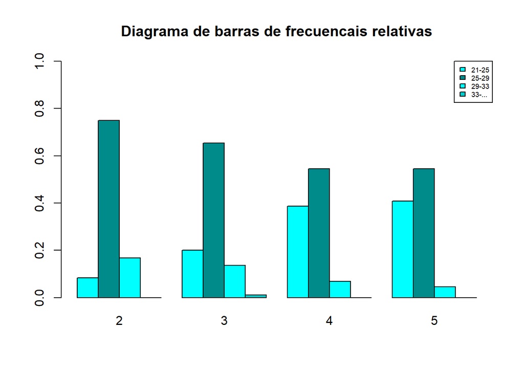

```r
azul=c("cyan","cyan4","cyan1","cyan3")
barplot(t(frecRel),
        beside = TRUE,
        legend=TRUE,
        ylim=c(0,1),
        col=azul,
        main="Diagrama de barras de frecuencais relativas",
        args.legend=list(x="topright",cex=0.55))
```

Graficando el grafico de frecuencias relativas acumuladas.

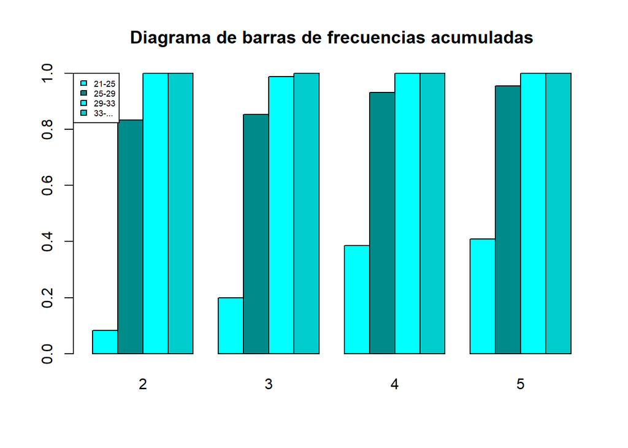

```r
barplot(frecRelAcum,
        beside = TRUE,
        legend=TRUE,
        col=azul,
        main="Diagrama de barras de frecuencias acumuladas",
        args.legend=list(x="topleft",cex=0.55)
        )
```